# Risk Factor Analysis

## Outcome Variable

**Outcome Variable:** sstunted

## Predictor Variables

**Intervention Variable:** exclfeed6

**Adjustment Set:**

unadjusted

## Stratifying Variables

The analysis was stratified on these variable(s):

- agecat
- studyid
- country

## Data Summary

| agecat | studyid | country | exclfeed6 | sstunted | n_cell | n | outcome_variable |
| --- | --- | --- | --- | --- | --- | --- | --- |
| Birth | ki0047075b-MAL-ED | BANGLADESH | 1 | 0 | 31 | 205 | sstunted |
| Birth | ki0047075b-MAL-ED | BANGLADESH | 1 | 1 | 0 | 205 | sstunted |
| Birth | ki0047075b-MAL-ED | BANGLADESH | 0 | 0 | 169 | 205 | sstunted |
| Birth | ki0047075b-MAL-ED | BANGLADESH | 0 | 1 | 5 | 205 | sstunted |
| Birth | ki0047075b-MAL-ED | BRAZIL | 1 | 0 | 1 | 60 | sstunted |
| Birth | ki0047075b-MAL-ED | BRAZIL | 1 | 1 | 1 | 60 | sstunted |
| Birth | ki0047075b-MAL-ED | BRAZIL | 0 | 0 | 56 | 60 | sstunted |
| Birth | ki0047075b-MAL-ED | BRAZIL | 0 | 1 | 2 | 60 | sstunted |
| Birth | ki0047075b-MAL-ED | INDIA | 1 | 0 | 1 | 39 | sstunted |
| Birth | ki0047075b-MAL-ED | INDIA | 1 | 1 | 0 | 39 | sstunted |
| Birth | ki0047075b-MAL-ED | INDIA | 0 | 0 | 36 | 39 | sstunted |
| Birth | ki0047075b-MAL-ED | INDIA | 0 | 1 | 2 | 39 | sstunted |
| Birth | ki0047075b-MAL-ED | NEPAL | 1 | 0 | 2 | 24 | sstunted |
| Birth | ki0047075b-MAL-ED | NEPAL | 1 | 1 | 0 | 24 | sstunted |
| Birth | ki0047075b-MAL-ED | NEPAL | 0 | 0 | 21 | 24 | sstunted |
| Birth | ki0047075b-MAL-ED | NEPAL | 0 | 1 | 1 | 24 | sstunted |
| Birth | ki0047075b-MAL-ED | PERU | 1 | 0 | 2 | 213 | sstunted |
| Birth | ki0047075b-MAL-ED | PERU | 1 | 1 | 0 | 213 | sstunted |
| Birth | ki0047075b-MAL-ED | PERU | 0 | 0 | 207 | 213 | sstunted |
| Birth | ki0047075b-MAL-ED | PERU | 0 | 1 | 4 | 213 | sstunted |
| Birth | ki0047075b-MAL-ED | SOUTH AFRICA | 1 | 0 | 0 | 91 | sstunted |
| Birth | ki0047075b-MAL-ED | SOUTH AFRICA | 1 | 1 | 0 | 91 | sstunted |
| Birth | ki0047075b-MAL-ED | SOUTH AFRICA | 0 | 0 | 90 | 91 | sstunted |
| Birth | ki0047075b-MAL-ED | SOUTH AFRICA | 0 | 1 | 1 | 91 | sstunted |
| Birth | ki0047075b-MAL-ED | TANZANIA, UNITED REPUBLIC OF | 1 | 0 | 0 | 113 | sstunted |
| Birth | ki0047075b-MAL-ED | TANZANIA, UNITED REPUBLIC OF | 1 | 1 | 0 | 113 | sstunted |
| Birth | ki0047075b-MAL-ED | TANZANIA, UNITED REPUBLIC OF | 0 | 0 | 105 | 113 | sstunted |
| Birth | ki0047075b-MAL-ED | TANZANIA, UNITED REPUBLIC OF | 0 | 1 | 8 | 113 | sstunted |
| Birth | ki1000108-CMC-V-BCS-2002 | INDIA | 1 | 0 | 7 | 7 | sstunted |
| Birth | ki1000108-CMC-V-BCS-2002 | INDIA | 1 | 1 | 0 | 7 | sstunted |

[output cut: 170 more lines]

The following strata were considered:

- agecat: 24 months, studyid: ki0047075b-MAL-ED, country: BANGLADESH
- agecat: 24 months, studyid: ki0047075b-MAL-ED, country: BRAZIL
- agecat: 24 months, studyid: ki0047075b-MAL-ED, country: INDIA
- agecat: 24 months, studyid: ki0047075b-MAL-ED, country: NEPAL
- agecat: 24 months, studyid: ki0047075b-MAL-ED, country: PERU
- agecat: 24 months, studyid: ki0047075b-MAL-ED, country: SOUTH AFRICA
- agecat: 24 months, studyid: ki0047075b-MAL-ED, country: TANZANIA, UNITED REPUBLIC OF
- agecat: 24 months, studyid: ki1000108-CMC-V-BCS-2002, country: INDIA
- agecat: 24 months, studyid: ki1000108-IRC, country: INDIA
- agecat: 24 months, studyid: ki1000109-EE, country: PAKISTAN
- agecat: 24 months, studyid: ki1017093b-PROVIDE, country: BANGLADESH
- agecat: 24 months, studyid: ki1101329-Keneba, country: GAMBIA
- agecat: 24 months, studyid: ki1113344-GMS-Nepal, country: NEPAL
- agecat: 24 months, studyid: ki1148112-LCNI-5, country: MALAWI
- agecat: 24 months, studyid: kiGH5241-JiVitA-3, country: BANGLADESH
- agecat: 24 months, studyid: kiGH5241-JiVitA-4, country: BANGLADESH
- agecat: 6 months, studyid: ki0047075b-MAL-ED, country: BANGLADESH
- agecat: 6 months, studyid: ki0047075b-MAL-ED, country: BRAZIL
- agecat: 6 months, studyid: ki0047075b-MAL-ED, country: INDIA
- agecat: 6 months, studyid: ki0047075b-MAL-ED, country: NEPAL
- agecat: 6 months, studyid: ki0047075b-MAL-ED, country: PERU
- agecat: 6 months, studyid: ki0047075b-MAL-ED, country: SOUTH AFRICA
- agecat: 6 months, studyid: ki0047075b-MAL-ED, country: TANZANIA, UNITED REPUBLIC OF
- agecat: 6 months, studyid: ki1000108-CMC-V-BCS-2002, country: INDIA
- agecat: 6 months, studyid: ki1000108-IRC, country: INDIA
- agecat: 6 months, studyid: ki1000109-EE, country: PAKISTAN
- agecat: 6 months, studyid: ki1000304b-SAS-CompFeed, country: INDIA
- agecat: 6 months, studyid: ki1000304b-SAS-FoodSuppl, country: INDIA
- agecat: 6 months, studyid: ki1017093b-PROVIDE, country: BANGLADESH
- agecat: 6 months, studyid: ki1101329-Keneba, country: GAMBIA
- agecat: 6 months, studyid: ki1113344-GMS-Nepal, country: NEPAL
- agecat: 6 months, studyid: ki1148112-LCNI-5, country: MALAWI
- agecat: 6 months, studyid: kiGH5241-JiVitA-3, country: BANGLADESH
- agecat: 6 months, studyid: kiGH5241-JiVitA-4, country: BANGLADESH
- agecat: Birth, studyid: ki0047075b-MAL-ED, country: BANGLADESH
- agecat: Birth, studyid: ki0047075b-MAL-ED, country: BRAZIL
- agecat: Birth, studyid: ki0047075b-MAL-ED, country: INDIA
- agecat: Birth, studyid: ki0047075b-MAL-ED, country: NEPAL
- agecat: Birth, studyid: ki0047075b-MAL-ED, country: PERU
- agecat: Birth, studyid: ki0047075b-MAL-ED, country: SOUTH AFRICA
- agecat: Birth, studyid: ki0047075b-MAL-ED, country: TANZANIA, UNITED REPUBLIC OF
- agecat: Birth, studyid: ki1000108-CMC-V-BCS-2002, country: INDIA
- agecat: Birth, studyid: ki1000108-IRC, country: INDIA
- agecat: Birth, studyid: ki1000109-EE, country: PAKISTAN
- agecat: Birth, studyid: ki1000304b-SAS-CompFeed, country: INDIA
- agecat: Birth, studyid: ki1017093b-PROVIDE, country: BANGLADESH
- agecat: Birth, studyid: ki1101329-Keneba, country: GAMBIA
- agecat: Birth, studyid: ki1113344-GMS-Nepal, country: NEPAL
- agecat: Birth, studyid: kiGH5241-JiVitA-3, country: BANGLADESH
- agecat: Birth, studyid: kiGH5241-JiVitA-4, country: BANGLADESH

### Dropped Strata

Some strata were dropped due to rare outcomes:

- agecat: Birth, studyid: ki0047075b-MAL-ED, country: BANGLADESH
- agecat: Birth, studyid: ki0047075b-MAL-ED, country: BRAZIL
- agecat: Birth, studyid: ki0047075b-MAL-ED, country: INDIA
- agecat: Birth, studyid: ki0047075b-MAL-ED, country: NEPAL
- agecat: Birth, studyid: ki0047075b-MAL-ED, country: PERU
- agecat: Birth, studyid: ki0047075b-MAL-ED, country: SOUTH AFRICA
- agecat: Birth, studyid: ki0047075b-MAL-ED, country: TANZANIA, UNITED REPUBLIC OF
- agecat: Birth, studyid: ki1000108-CMC-V-BCS-2002, country: INDIA
- agecat: Birth, studyid: ki1000108-IRC, country: INDIA
- agecat: Birth, studyid: ki1000109-EE, country: PAKISTAN
- agecat: Birth, studyid: ki1000304b-SAS-CompFeed, country: INDIA
- agecat: Birth, studyid: ki1017093b-PROVIDE, country: BANGLADESH
- agecat: 6 months, studyid: ki0047075b-MAL-ED, country: BANGLADESH
- agecat: 6 months, studyid: ki0047075b-MAL-ED, country: BRAZIL
- agecat: 6 months, studyid: ki0047075b-MAL-ED, country: INDIA
- agecat: 6 months, studyid: ki0047075b-MAL-ED, country: NEPAL
- agecat: 6 months, studyid: ki0047075b-MAL-ED, country: PERU
- agecat: 6 months, studyid: ki0047075b-MAL-ED, country: SOUTH AFRICA
- agecat: 6 months, studyid: ki0047075b-MAL-ED, country: TANZANIA, UNITED REPUBLIC OF
- agecat: 6 months, studyid: ki1000108-CMC-V-BCS-2002, country: INDIA
- agecat: 6 months, studyid: ki1000108-IRC, country: INDIA
- agecat: 6 months, studyid: ki1000109-EE, country: PAKISTAN
- agecat: 6 months, studyid: ki1000304b-SAS-CompFeed, country: INDIA
- agecat: 6 months, studyid: ki1000304b-SAS-FoodSuppl, country: INDIA
- agecat: 6 months, studyid: ki1017093b-PROVIDE, country: BANGLADESH
- agecat: 6 months, studyid: ki1148112-LCNI-5, country: MALAWI
- agecat: 24 months, studyid: ki0047075b-MAL-ED, country: BRAZIL
- agecat: 24 months, studyid: ki0047075b-MAL-ED, country: INDIA
- agecat: 24 months, studyid: ki0047075b-MAL-ED, country: NEPAL
- agecat: 24 months, studyid: ki0047075b-MAL-ED, country: PERU
- agecat: 24 months, studyid: ki0047075b-MAL-ED, country: SOUTH AFRICA
- agecat: 24 months, studyid: ki0047075b-MAL-ED, country: TANZANIA, UNITED REPUBLIC OF
- agecat: 24 months, studyid: ki1000108-CMC-V-BCS-2002, country: INDIA
- agecat: 24 months, studyid: ki1000108-IRC, country: INDIA
- agecat: 24 months, studyid: ki1000109-EE, country: PAKISTAN
- agecat: 24 months, studyid: ki1148112-LCNI-5, country: MALAWI

## Methods Detail

We’re interested in the causal parameters $E[Y_a]$ for all values of $a \in \mathcal{A}$. These parameters represent the mean outcome if, possibly contrary to fact, we intervened to set all units to have $A=a$. Under the randomization and positivity assumptions, these are identified by the statistical parameters $\psi_a=E_W[E_{Y|A,W}(Y|A=a,W)]$. In addition, we’re interested in the mean of $Y$, $E[Y]$ under no intervention (the observed mean). We will estimate these parameters by using SuperLearner to fit the relevant likelihood factors – $E_{Y|A,W}(Y|A=a,W)$ and $p(A=a|W)$, and then updating our likelihood fit using a joint TMLE.

For unadjusted analyses ($W=\{\}$), initial likelihoods were estimated using Lrnr_glm to estimate the simple $E(Y|A)$ and Lrnr_mean to estimate $p(A)$. For adjusted analyses, a small library containing Lrnr_glmnet, Lrnr_xgboost, and Lrnr_mean was used.

Having estimated these parameters, we will then use the delta method to estimate relative risks and attributable risks relative to a prespecified baseline level of $A$.

# Results Detail

## Results Plots

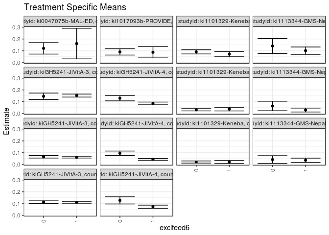

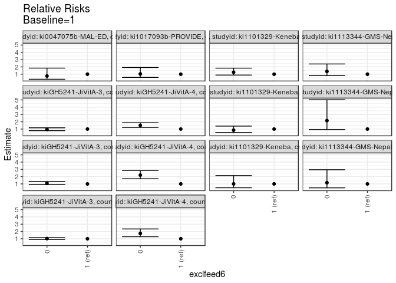

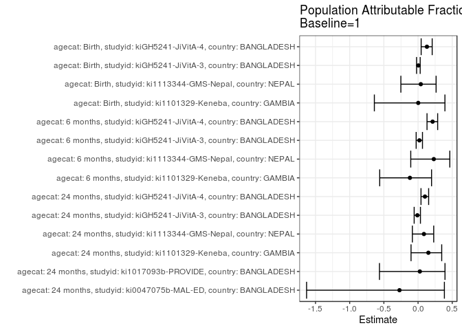

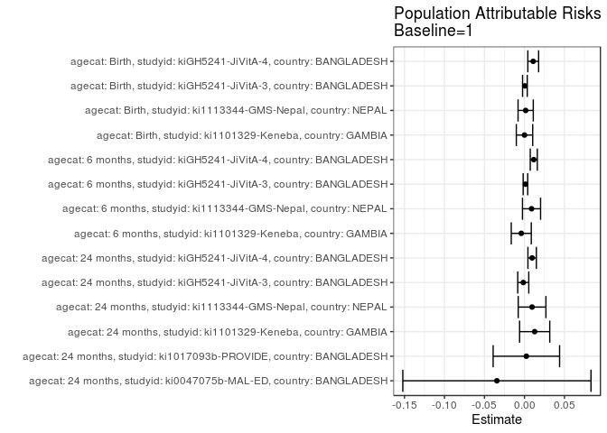

## Results Table

### Parameter: TSM

| agecat | studyid | country | intervention_level | baseline_level | estimate | ci_lower | ci_upper |
| --- | --- | --- | --- | --- | --- | --- | --- |
| Birth | ki1101329-Keneba | GAMBIA | 1 | NA | 0.0206186 | 0.0079672 | 0.0332699 |
| Birth | ki1101329-Keneba | GAMBIA | 0 | NA | 0.0206972 | 0.0114843 | 0.0299101 |
| Birth | ki1113344-GMS-Nepal | NEPAL | 1 | NA | 0.0357995 | 0.0179942 | 0.0536048 |
| Birth | ki1113344-GMS-Nepal | NEPAL | 0 | NA | 0.0416667 | 0.0089999 | 0.0743334 |
| Birth | kiGH5241-JiVitA-3 | BANGLADESH | 1 | NA | 0.1099311 | 0.1032640 | 0.1165982 |
| Birth | kiGH5241-JiVitA-3 | BANGLADESH | 0 | NA | 0.1124201 | 0.1010127 | 0.1238275 |
| Birth | kiGH5241-JiVitA-4 | BANGLADESH | 1 | NA | 0.0734032 | 0.0598878 | 0.0869187 |
| Birth | kiGH5241-JiVitA-4 | BANGLADESH | 0 | NA | 0.1273408 | 0.0970060 | 0.1576756 |
| 6 months | ki1101329-Keneba | GAMBIA | 1 | NA | 0.0375427 | 0.0221481 | 0.0529372 |
| 6 months | ki1101329-Keneba | GAMBIA | 0 | NA | 0.0317700 | 0.0223132 | 0.0412268 |
| 6 months | ki1113344-GMS-Nepal | NEPAL | 1 | NA | 0.0295567 | 0.0130676 | 0.0460457 |
| 6 months | ki1113344-GMS-Nepal | NEPAL | 0 | NA | 0.0638298 | 0.0234443 | 0.1042152 |
| 6 months | kiGH5241-JiVitA-3 | BANGLADESH | 1 | NA | 0.0603041 | 0.0545655 | 0.0660428 |
| 6 months | kiGH5241-JiVitA-3 | BANGLADESH | 0 | NA | 0.0655521 | 0.0544280 | 0.0766763 |
| 6 months | kiGH5241-JiVitA-4 | BANGLADESH | 1 | NA | 0.0431242 | 0.0358930 | 0.0503555 |
| 6 months | kiGH5241-JiVitA-4 | BANGLADESH | 0 | NA | 0.0951883 | 0.0766795 | 0.1136970 |
| 24 months | ki0047075b-MAL-ED | BANGLADESH | 1 | NA | 0.1612903 | 0.0315010 | 0.2910797 |
| 24 months | ki0047075b-MAL-ED | BANGLADESH | 0 | NA | 0.1206897 | 0.0721673 | 0.1692120 |
| 24 months | ki1017093b-PROVIDE | BANGLADESH | 1 | NA | 0.0875912 | 0.0402119 | 0.1349706 |
| 24 months | ki1017093b-PROVIDE | BANGLADESH | 0 | NA | 0.0907029 | 0.0638762 | 0.1175297 |
| 24 months | ki1101329-Keneba | GAMBIA | 1 | NA | 0.0718447 | 0.0495349 | 0.0941545 |
| 24 months | ki1101329-Keneba | GAMBIA | 0 | NA | 0.0911824 | 0.0733167 | 0.1090481 |
| 24 months | ki1113344-GMS-Nepal | NEPAL | 1 | NA | 0.1011236 | 0.0697718 | 0.1324754 |
| 24 months | ki1113344-GMS-Nepal | NEPAL | 0 | NA | 0.1403509 | 0.0765207 | 0.2041811 |
| 24 months | kiGH5241-JiVitA-3 | BANGLADESH | 1 | NA | 0.1524515 | 0.1397026 | 0.1652004 |
| 24 months | kiGH5241-JiVitA-3 | BANGLADESH | 0 | NA | 0.1459044 | 0.1182377 | 0.1735712 |
| 24 months | kiGH5241-JiVitA-4 | BANGLADESH | 1 | NA | 0.0856707 | 0.0742718 | 0.0970696 |
| 24 months | kiGH5241-JiVitA-4 | BANGLADESH | 0 | NA | 0.1294886 | 0.1075557 | 0.1514215 |

### Parameter: E(Y)

| agecat | studyid | country | intervention_level | baseline_level | estimate | ci_lower | ci_upper |
| --- | --- | --- | --- | --- | --- | --- | --- |
| Birth | ki1101329-Keneba | GAMBIA | NA | NA | 0.0206700 | 0.0132225 | 0.0281175 |
| Birth | ki1113344-GMS-Nepal | NEPAL | NA | NA | 0.0373002 | 0.0216334 | 0.0529670 |
| Birth | kiGH5241-JiVitA-3 | BANGLADESH | NA | NA | 0.1104820 | 0.1047181 | 0.1162459 |
| Birth | kiGH5241-JiVitA-4 | BANGLADESH | NA | NA | 0.0843465 | 0.0720577 | 0.0966353 |
| 6 months | ki1101329-Keneba | GAMBIA | NA | NA | 0.0335430 | 0.0254620 | 0.0416240 |
| 6 months | ki1113344-GMS-Nepal | NEPAL | NA | NA | 0.0383912 | 0.0222749 | 0.0545076 |
| 6 months | kiGH5241-JiVitA-3 | BANGLADESH | NA | NA | 0.0615089 | 0.0563485 | 0.0666694 |
| 6 months | kiGH5241-JiVitA-4 | BANGLADESH | NA | NA | 0.0547753 | 0.0477475 | 0.0618030 |
| 24 months | ki0047075b-MAL-ED | BANGLADESH | NA | NA | 0.1268293 | 0.0811633 | 0.1724952 |
| 24 months | ki1017093b-PROVIDE | BANGLADESH | NA | NA | 0.0899654 | 0.0666186 | 0.1133122 |
| 24 months | ki1101329-Keneba | GAMBIA | NA | NA | 0.0846001 | 0.0705732 | 0.0986271 |
| 24 months | ki1113344-GMS-Nepal | NEPAL | NA | NA | 0.1106383 | 0.0822491 | 0.1390275 |
| 24 months | kiGH5241-JiVitA-3 | BANGLADESH | NA | NA | 0.1509434 | 0.1390224 | 0.1628644 |
| 24 months | kiGH5241-JiVitA-4 | BANGLADESH | NA | NA | 0.0952608 | 0.0849096 | 0.1056119 |

### Parameter: RR

| agecat | studyid | country | intervention_level | baseline_level | estimate | ci_lower | ci_upper |
| --- | --- | --- | --- | --- | --- | --- | --- |
| Birth | ki1101329-Keneba | GAMBIA | 1 | 1 | 1.0000000 | 1.0000000 | 1.000000 |
| Birth | ki1101329-Keneba | GAMBIA | 0 | 1 | 1.0038126 | 0.4703681 | 2.142237 |
| Birth | ki1113344-GMS-Nepal | NEPAL | 1 | 1 | 1.0000000 | 1.0000000 | 1.000000 |
| Birth | ki1113344-GMS-Nepal | NEPAL | 0 | 1 | 1.1638889 | 0.4599272 | 2.945330 |
| Birth | kiGH5241-JiVitA-3 | BANGLADESH | 1 | 1 | 1.0000000 | 1.0000000 | 1.000000 |
| Birth | kiGH5241-JiVitA-3 | BANGLADESH | 0 | 1 | 1.0226410 | 0.9084573 | 1.151176 |
| Birth | kiGH5241-JiVitA-4 | BANGLADESH | 1 | 1 | 1.0000000 | 1.0000000 | 1.000000 |
| Birth | kiGH5241-JiVitA-4 | BANGLADESH | 0 | 1 | 1.7348120 | 1.2817938 | 2.347938 |
| 6 months | ki1101329-Keneba | GAMBIA | 1 | 1 | 1.0000000 | 1.0000000 | 1.000000 |
| 6 months | ki1101329-Keneba | GAMBIA | 0 | 1 | 0.8462385 | 0.5098404 | 1.404596 |
| 6 months | ki1113344-GMS-Nepal | NEPAL | 1 | 1 | 1.0000000 | 1.0000000 | 1.000000 |
| 6 months | ki1113344-GMS-Nepal | NEPAL | 0 | 1 | 2.1595745 | 0.9290246 | 5.020063 |
| 6 months | kiGH5241-JiVitA-3 | BANGLADESH | 1 | 1 | 1.0000000 | 1.0000000 | 1.000000 |
| 6 months | kiGH5241-JiVitA-3 | BANGLADESH | 0 | 1 | 1.0870254 | 0.8966421 | 1.317833 |
| 6 months | kiGH5241-JiVitA-4 | BANGLADESH | 1 | 1 | 1.0000000 | 1.0000000 | 1.000000 |
| 6 months | kiGH5241-JiVitA-4 | BANGLADESH | 0 | 1 | 2.2073030 | 1.7102459 | 2.848822 |
| 24 months | ki0047075b-MAL-ED | BANGLADESH | 1 | 1 | 1.0000000 | 1.0000000 | 1.000000 |
| 24 months | ki0047075b-MAL-ED | BANGLADESH | 0 | 1 | 0.7482759 | 0.3043666 | 1.839613 |
| 24 months | ki1017093b-PROVIDE | BANGLADESH | 1 | 1 | 1.0000000 | 1.0000000 | 1.000000 |
| 24 months | ki1017093b-PROVIDE | BANGLADESH | 0 | 1 | 1.0355253 | 0.5590115 | 1.918230 |
| 24 months | ki1101329-Keneba | GAMBIA | 1 | 1 | 1.0000000 | 1.0000000 | 1.000000 |
| 24 months | ki1101329-Keneba | GAMBIA | 0 | 1 | 1.2691599 | 0.8791319 | 1.832224 |
| 24 months | ki1113344-GMS-Nepal | NEPAL | 1 | 1 | 1.0000000 | 1.0000000 | 1.000000 |
| 24 months | ki1113344-GMS-Nepal | NEPAL | 0 | 1 | 1.3879142 | 0.8004256 | 2.406602 |
| 24 months | kiGH5241-JiVitA-3 | BANGLADESH | 1 | 1 | 1.0000000 | 1.0000000 | 1.000000 |
| 24 months | kiGH5241-JiVitA-3 | BANGLADESH | 0 | 1 | 0.9570549 | 0.7804411 | 1.173636 |
| 24 months | kiGH5241-JiVitA-4 | BANGLADESH | 1 | 1 | 1.0000000 | 1.0000000 | 1.000000 |
| 24 months | kiGH5241-JiVitA-4 | BANGLADESH | 0 | 1 | 1.5114681 | 1.2262566 | 1.863016 |

### Parameter: PAR

| agecat | studyid | country | intervention_level | baseline_level | estimate | ci_lower | ci_upper |
| --- | --- | --- | --- | --- | --- | --- | --- |
| Birth | ki1101329-Keneba | GAMBIA | 1 | NA | 0.0000514 | -0.0101888 | 0.0102917 |
| Birth | ki1113344-GMS-Nepal | NEPAL | 1 | NA | 0.0015007 | -0.0080175 | 0.0110188 |
| Birth | kiGH5241-JiVitA-3 | BANGLADESH | 1 | NA | 0.0005509 | -0.0023775 | 0.0034793 |
| Birth | kiGH5241-JiVitA-4 | BANGLADESH | 1 | NA | 0.0109433 | 0.0042057 | 0.0176808 |
| 6 months | ki1101329-Keneba | GAMBIA | 1 | NA | -0.0039997 | -0.0165185 | 0.0085191 |
| 6 months | ki1113344-GMS-Nepal | NEPAL | 1 | NA | 0.0088346 | -0.0024799 | 0.0201491 |
| 6 months | kiGH5241-JiVitA-3 | BANGLADESH | 1 | NA | 0.0012048 | -0.0016384 | 0.0040480 |
| 6 months | kiGH5241-JiVitA-4 | BANGLADESH | 1 | NA | 0.0116510 | 0.0072467 | 0.0160554 |
| 24 months | ki0047075b-MAL-ED | BANGLADESH | 1 | NA | -0.0344611 | -0.1520875 | 0.0831654 |
| 24 months | ki1017093b-PROVIDE | BANGLADESH | 1 | NA | 0.0023742 | -0.0391677 | 0.0439160 |
| 24 months | ki1101329-Keneba | GAMBIA | 1 | NA | 0.0127555 | -0.0061031 | 0.0316141 |
| 24 months | ki1113344-GMS-Nepal | NEPAL | 1 | NA | 0.0095147 | -0.0078013 | 0.0268307 |
| 24 months | kiGH5241-JiVitA-3 | BANGLADESH | 1 | NA | -0.0015081 | -0.0084058 | 0.0053897 |
| 24 months | kiGH5241-JiVitA-4 | BANGLADESH | 1 | NA | 0.0095900 | 0.0043222 | 0.0148579 |

### Parameter: PAF

| agecat | studyid | country | intervention_level | baseline_level | estimate | ci_lower | ci_upper |
| --- | --- | --- | --- | --- | --- | --- | --- |
| Birth | ki1101329-Keneba | GAMBIA | 1 | NA | 0.0024884 | -0.6391187 | 0.3929486 |
| Birth | ki1113344-GMS-Nepal | NEPAL | 1 | NA | 0.0402318 | -0.2514084 | 0.2639055 |
| Birth | kiGH5241-JiVitA-3 | BANGLADESH | 1 | NA | 0.0049863 | -0.0218982 | 0.0311635 |
| Birth | kiGH5241-JiVitA-4 | BANGLADESH | 1 | NA | 0.1297418 | 0.0453525 | 0.2066711 |
| 6 months | ki1101329-Keneba | GAMBIA | 1 | NA | -0.1192406 | -0.5607925 | 0.1973952 |
| 6 months | ki1113344-GMS-Nepal | NEPAL | 1 | NA | 0.2301196 | -0.1068011 | 0.4644785 |
| 6 months | kiGH5241-JiVitA-3 | BANGLADESH | 1 | NA | 0.0195873 | -0.0276696 | 0.0646712 |
| 6 months | kiGH5241-JiVitA-4 | BANGLADESH | 1 | NA | 0.2127061 | 0.1310180 | 0.2867150 |
| 24 months | ki0047075b-MAL-ED | BANGLADESH | 1 | NA | -0.2717122 | -1.6302666 | 0.3851377 |
| 24 months | ki1017093b-PROVIDE | BANGLADESH | 1 | NA | 0.0263897 | -0.5643707 | 0.3940585 |
| 24 months | ki1101329-Keneba | GAMBIA | 1 | NA | 0.1507737 | -0.1025949 | 0.3459199 |
| 24 months | ki1113344-GMS-Nepal | NEPAL | 1 | NA | 0.0859983 | -0.0832793 | 0.2288239 |
| 24 months | kiGH5241-JiVitA-3 | BANGLADESH | 1 | NA | -0.0099911 | -0.0568816 | 0.0348191 |
| 24 months | kiGH5241-JiVitA-4 | BANGLADESH | 1 | NA | 0.1006715 | 0.0430181 | 0.1548516 |